# Faith_Act3

Hannah Lasquite

2026-06-01

# A. Read and perform descriptive statistics

*1. Read in the CSV file as a dataframe using the function “read.csv”. Make sure to clean the data prior to performing the tasks below. Do not attempt to clean the data in Excel. Perform all cleaning (e.g., NA removal) in R using the code we discussed.*

```r
getwd()
```

```
## [1] "C:/Users/Acer/Desktop/LifeDat Projects/Act 3"
```

```r
setwd("C:/Users/Acer/Desktop/LifeDat Projects/Act 3")

rawdata<-read.csv("herpetozoa-033-095-s001.csv")

if (any(is.na(rawdata)) == T){print(sum(is.na(rawdata)))}
```

```
## [1] 124
```

```r
##To check if there is any NA values and how many

compdata <- complete.cases(rawdata)

head(rawdata[compdata, ])
```

```
##      Sites     Long     Lat Htypes Elev SPPTotal Babu Inph Liac Lipa Ocla Leta
## 1 ASG_ET1# 118.3962 9.37437    ASG  257        0    0    0    0    0    0    0
## 2 ASG_ET4# 118.3990 9.37250    ASG  215        0    0    0    0    0    0    0
## 3 ESG_ET5# 118.4008 9.37183    ESG  188        0    0    0    0    0    0    0
## 4  CVT_ET6 118.4056 9.36728    CVT  105        0    0    0    0    0    0    0
## 5  OGF_ET8 118.3861 9.37160    OGF  662        1    0    0    0    0    0    0
## 6 OGF_ET10 118.3840 9.37247    OGF  754        1    0    0    0    0    0    0
##   Meli Chfu Pumo Sasa Stnu Phev Phlo Pole Poma Brsp Cyre Geat Gege Gemo Hety
## 1    0    0    0    0    0    0    0    0    0    0    0    0    0    0    0
## 2    0    0    0    0    0    0    0    0    0    0    0    0    0    0    0
## 3    0    0    0    0    0    0    0    0    0    0    0    0    0    0    0
## 4    0    0    0    0    0    0    0    0    0    0    0    0    0    0    0
## 5    0    0    0    0    0    0    3    0    0    0    0    0    0    0    0
## 6    0    0    0    0    0    0    7    0    0    0    0    0    0    0    0
##   Eumu Bosc Dema Drru Apbo Trsu
## 1    0    0    0    0    0    0
## 2    0    0    0    0    0    0
## 3    0    0    0    0    0    0
## 4    0    0    0    0    0    0
## 5    0    0    0    0    0    0
## 6    0    0    0    0    0    0
```

```r
herpdata <- rawdata[compdata, ]

if (any(is.na(herpdata)) == T){print(sum(is.na(herpdata)))}
##Double check if there is NA values, if nothing is printed then we good to go
```

*2. Show the data structure.*

```r
class(herpdata)
```

```
## [1] "data.frame"
```

```r
str(herpdata)
```

```
## 'data.frame':    49 obs. of  33 variables:
##  $ Sites   : chr  "ASG_ET1#" "ASG_ET4#" "ESG_ET5#" "CVT_ET6" ...
##  $ Long    : num  118 118 118 118 118 ...
##  $ Lat     : num  9.37 9.37 9.37 9.37 9.37 ...
##  $ Htypes  : chr  "ASG" "ASG" "ESG" "CVT" ...
##  $ Elev    : int  257 215 188 105 662 754 814 1020 474 425 ...
##  $ SPPTotal: int  0 0 0 0 1 1 1 1 1 1 ...
##  $ Babu    : int  0 0 0 0 0 0 0 0 0 0 ...
##  $ Inph    : int  0 0 0 0 0 0 0 0 0 0 ...
##  $ Liac    : int  0 0 0 0 0 0 0 0 0 0 ...
##  $ Lipa    : int  0 0 0 0 0 0 0 0 0 0 ...
##  $ Ocla    : int  0 0 0 0 0 0 0 0 0 0 ...
##  $ Leta    : int  0 0 0 0 0 0 0 0 0 0 ...
##  $ Meli    : int  0 0 0 0 0 0 0 0 0 0 ...
##  $ Chfu    : int  0 0 0 0 0 0 0 0 0 0 ...
```

[output cut: 19 more lines]

*3. Subset the elevation data and provide the mean, standard deviation, and range*

```r
Elev <- herpdata[,5]
mean(Elev)
```

```
## [1] 379.3878
```

```r
sd(Elev)
```

```
## [1] 240.5951
```

```r
range(Elev)
```

```
## [1]   60 1020
```

```r
##Just to check if the min and max values are correct

range <- (max(Elev)-min(Elev))
range
```

```
## [1] 960
```

*4. Subset the species data (columns G to AG) and count the total number of observations per species. Show two methods, using a typical loop and a compact loop. Which species has the most and the fewest observations?*

```r
Obs <- herpdata[, 7:33]

##typical ((Full credit to Jae who helped me with this part))
typObs <- 0
for(i in seq_len(ncol(Obs))) {
  typObs[i] <- (sum(Obs[i]))
}

typObstab <- matrix(typObs, nrow= 27, ncol = 1)
dimnames(typObstab) <- list(names(Obs), "Observation Sums")
typObstab
```

```
##      Observation Sums
## Babu                1
## Inph                4
## Liac               28
## Lipa                2
## Ocla                5
## Leta               39
## Meli               17
## Chfu                7
## Pumo               51
## Sasa                8
## Stnu               35
## Phev                2
## Phlo              377
## Pole                2
## Poma                5
## Brsp                6
## Cyre                7
## Geat                1
## Gege                5
## Gemo                7
## Hety                1
## Eumu                2
## Bosc                1
## Dema                2
## Drru                1
## Apbo                1
## Trsu                2
```

```r
##To see the Observation Sums with the corresponding species names

##compact
compactObs <- sapply(Obs,sum)
compactObs
```

```
## Babu Inph Liac Lipa Ocla Leta Meli Chfu Pumo Sasa Stnu Phev Phlo Pole Poma Brsp
##    1    4   28    2    5   39   17    7   51    8   35    2  377    2    5    6
## Cyre Geat Gege Gemo Hety Eumu Bosc Dema Drru Apbo Trsu
##    7    1    5    7    1    2    1    2    1    1    2
```

```r
max(compactObs)
```

```
## [1] 377
```

```r
min(compactObs)
```

```
## [1] 1
```

```r
##shows the max and min values

which(compactObs == max(compactObs))
```

```
## Phlo
##   13
```

```r
which(compactObs == min(compactObs))
```

```
## Babu Geat Hety Bosc Drru Apbo
##    1   18   21   23   25   26
```

```r
##shows column names and column number of max and min values
```

*5. Combine the columns of species with the most and fewest observations with habitat types (Htypes). Determine the mean count of these species in each habitat type. Which habitat type has the most species counts?*

```r
herphab <- herpdata[c("Htypes","Phlo","Babu","Geat","Hety","Bosc","Drru","Apbo")]

habA <- herphab[herphab$Htypes == "ASG",-1]
habC <- herphab[herphab$Htypes == "CVT",-1]
habE <- herphab[herphab$Htypes == "ESG",-1]
habO <- herphab[herphab$Htypes == "OGF",-1]

Amean <- sapply(habA,mean)
Cmean <- sapply(habC,mean)
Emean <- sapply(habE,mean)
Omean <- sapply(habO,mean)
##compact loop to get each mean per habitat type

habtot <- cbind(Amean, Cmean, Emean, Omean)
habtot
```

```
##           Amean Cmean Emean       Omean
## Phlo 1.46666667     4     0 15.08695652
## Babu 0.00000000     0     0  0.04347826
## Geat 0.00000000     0     0  0.04347826
## Hety 0.06666667     0     0  0.00000000
## Bosc 0.06666667     0     0  0.00000000
## Drru 0.06666667     0     0  0.00000000
## Apbo 0.00000000     0     0  0.04347826
```

```r
##To print all means in 1 matrix.OGF is the habitat with the highest mean under the Phlo species with ~15 observation average

Asum <- sapply(habA, sum)
Csum <- sapply(habC, sum)
Esum <- sapply(habE, sum)
Osum <- sapply(habO, sum)
##compact loop to get each sum per habitat type

habsum <- cbind(Asum,Csum,Esum,Osum)
habsum
```

```
##      Asum Csum Esum Osum
## Phlo   22    8    0  347
## Babu    0    0    0    1
## Geat    0    0    0    1
## Hety    1    0    0    0
## Bosc    1    0    0    0
## Drru    1    0    0    0
## Apbo    0    0    0    1
```

```r
##To print all sums in 1 matrix.OGF is the habitat with the highest sum under the Phlo species with 347 total observations
```

# B. Graphical representation

*1. From the original dataframe, combine the species total count column (SPPTotal) with the elevation and habitat type columns and create a scatter plot where elevation should be on the x-axis, while species total count is on the y-axis. Change the point colors based on habitat type. Are there habitat types with no species observations? What are these?*

```r
splotdat <- herpdata[,4:6]
splotdat
```

```
##    Htypes Elev SPPTotal
## 1     ASG  257        0
## 2     ASG  215        0
## 3     ESG  188        0
## 4     CVT  105        0
## 5     OGF  662        1
## 6     OGF  754        1
## 7     OGF  814        1
## 8     OGF 1020        1
## 9     OGF  474        1
## 10    OGF  425        1
## 11    OGF  507        1
## 12    OGF  537        1
## 13    OGF  686        1
## 14    CVT  778        1
```

[output cut: 35 more lines]

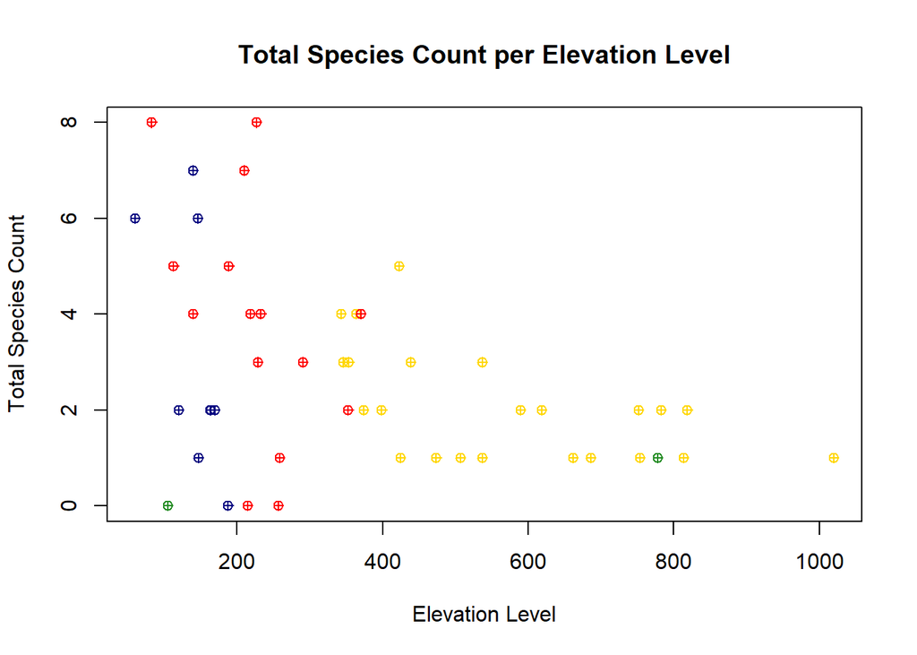

```r
splotcol <- c(ASG ="red1", CVT ="forestgreen", ESG = "navyblue", OGF="gold1")
##Choosing colors that are as different from each other as possible

plot(
  splotdat$Elev,
  splotdat$SPPTotal,
  col = splotcol[splotdat$Htypes],
  pch = 10,
  main = "Total Species Count per Elevation Level",
  xlab = "Elevation Level",
  ylab ="Total Species Count")
```

```r
##Added a main title, x-axis title, y-axis title and changed the shape for fun also clarity

#All colors are present therefore every habitat type had atleast 1 observation
```

*2. From the combined data of species total counts, elevation, and habitat types, determine the total/sum number of species observed per habitat, and create a bar plot (use the bar plot help) where the x-axis shows the habitat types and the y-axis shows the total species.*

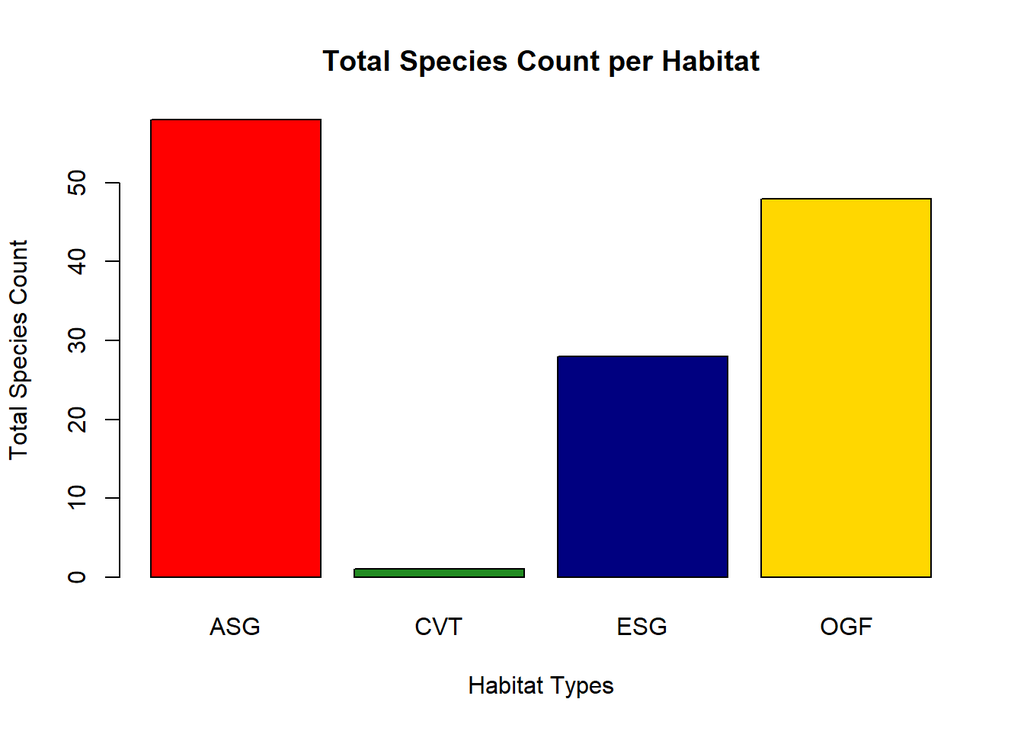

```r
SSPA <- sum(splotdat[splotdat$Htypes == "ASG",-(1:2)])
SSPC <- sum(splotdat[splotdat$Htypes == "CVT",-(1:2)])
SSPE <- sum(splotdat[splotdat$Htypes == "ESG",-(1:2)])
SSPO <- sum(splotdat[splotdat$Htypes == "OGF",-(1:2)])
##Subsets per habitat, removes first and second column indicating habitat type and elevation. Presence of both can interfere with the sum compact loop

bardat <- c(SSPA, SSPC, SSPE, SSPO)

barplot(
  bardat,
  names.arg = c("ASG","CVT","ESG","OGF"),
  main = "Total Species Count per Habitat",
  xlab = "Habitat Types",
  ylab ="Total Species Count",
  col =splotcol)
```

*3. Lastly, create a histogram of total species counts using the histogram function. Make sure all axes are properly labeled.*

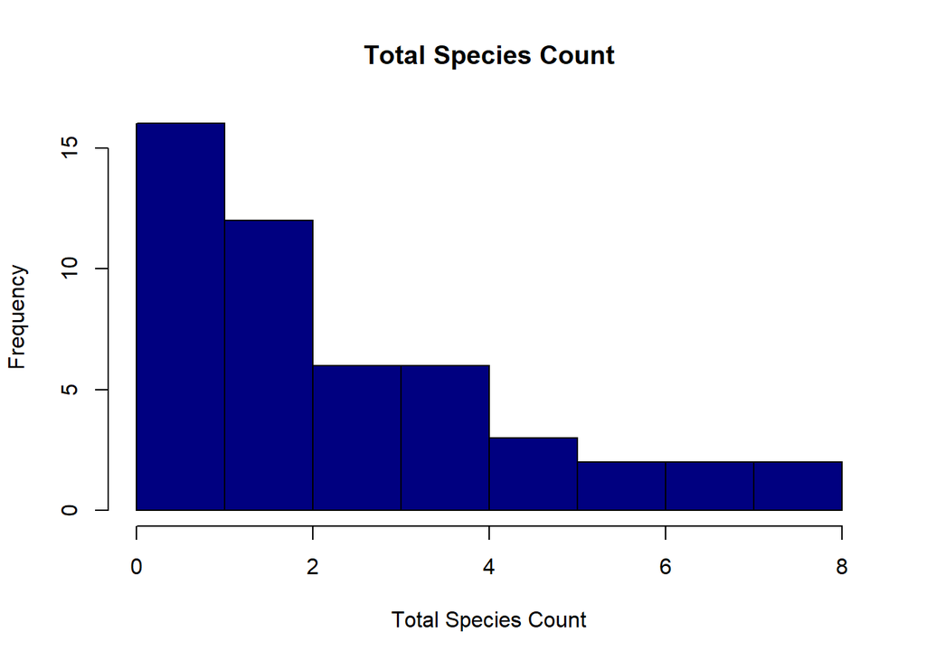

```r
hist(
  splotdat$SPPTotal,
  main = "Total Species Count",
  xlab = "Total Species Count",
  ylab = "Frequency",
  col ="navyblue"
)
```

```r
#Added navy blue color since gray just looks sad
```

# C.1

**Based on the summary statistics and preliminary graphs you just created, how do you describe the relationship between total species observed and habitat types and elevation?**